# Newton’s Method for Constrained Optimization (BV Chapters 10, 11)

### 2.1 Barrier method

- Alternative form makes inequality constraints implicit in the objective
  $$\begin{eqnarray*}
  &\text{minimize}& f_0(\mathbf{x}) + \sum_{i=1}^m I_-(f_i(\mathbf{x})) \\
  &\text{subject to}& \mathbf{A} \mathbf{x} = \mathbf{b},
  \end{eqnarray*}$$
  where
  $$\begin{eqnarray*}
  I_-(u) = \begin{cases}
  0 & u \le 0 \\
  \infty & u > 0
  \end{cases}.
  \end{eqnarray*}$$
- The idea of the barrier method is to approximate $I_-$ by a differentiable function
  $$\begin{eqnarray*}
  \hat I_-(u) = - (1/t) \log (-u), \quad u < 0,
  \end{eqnarray*}$$
  where $t>0$ is a parameter tuning the approximation accuracy. As $t$ increases, the approximation becomes more accurate.

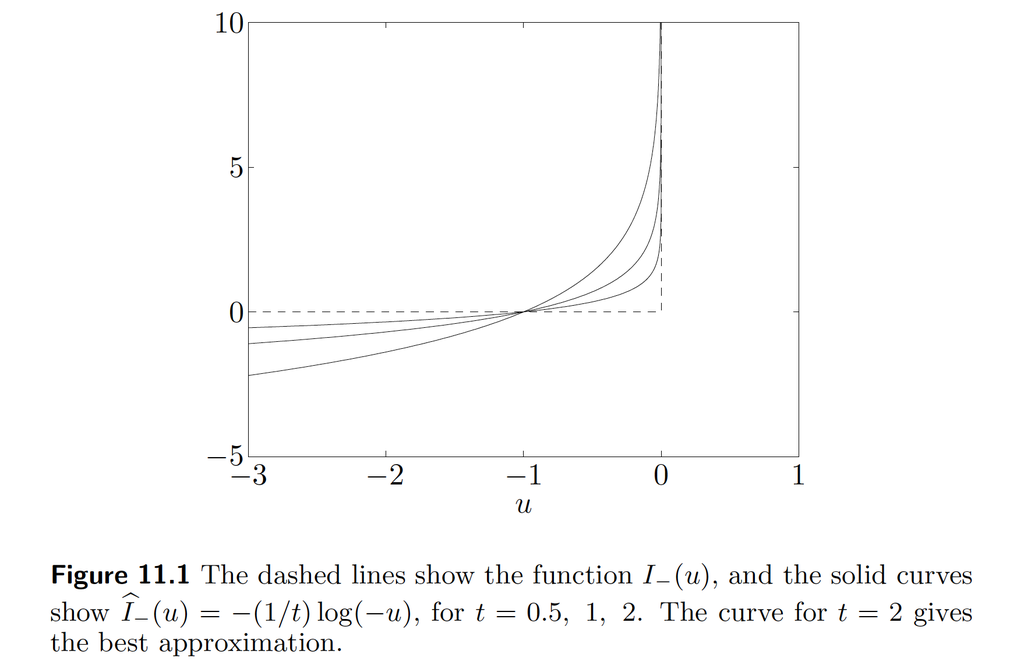

- The **barrier method** solves a sequence of equality-constraint problems
  $$\begin{eqnarray*}
  &\text{minimize}& t f_0(\mathbf{x}) - \sum_{i=1}^m \log(-f_i(\mathbf{x})) \\
  &\text{subject to}& \mathbf{A} \mathbf{x} = \mathbf{b},
  \end{eqnarray*}$$
  increasing the parameter $t$ at each step and starting each Newton minimization at the solution for the previous value of $t$.
- The function $\phi(\mathbf{x}) = - \sum_{i=1}^m \log (-f_i(\mathbf{x}))$ is called the **logarithmic barrier** or **log barrier** function.
- Denote the solution at $t$ by $\mathbf{x}^\star(t)$. Using duality theory, it can be shown
  $$\begin{eqnarray*}
  f_0(\mathbf{x}^\star(t)) - p^\star \le m / t.
  \end{eqnarray*}$$

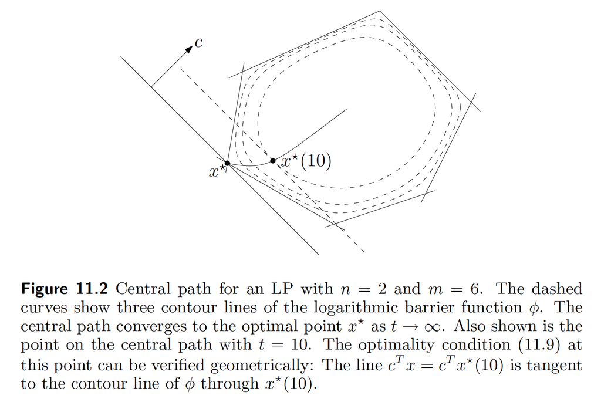

- Feasibility and phase I methods. Barrier method has to start from a **strictly feasible point**. We can find such a point by solving
  $$\begin{eqnarray*}
  &\text{minimize}& s \\
  &\text{subject to}& f_i(\mathbf{x}) \le s, \quad i = 1,\ldots,m \\
  & & \mathbf{A} \mathbf{x} = \mathbf{b}
  \end{eqnarray*}$$
  by the barrier method.

### 2.2 Primal-dual interior-point method

- Difference from barrier method: no double loop.
- In the barrier method, it can be show that a point $\mathbf{x}$ is equal to $\mathbf{x}^\star(t)$ if and only if
  $$\begin{eqnarray*}
  \nabla f_0(\mathbf{x}) + \sum_{i=1}^m \lambda_i \nabla f_i(\mathbf{x}) + \mathbf{A}^T \nu &=& \mathbf{0} \\
  \, - \lambda_i f_i(\mathbf{x}) &=& 1/t, \quad i = 1,\ldots,m \\
  \mathbf{A} \mathbf{x} &=& \mathbf{b}.
  \end{eqnarray*}$$
- We define the KKT residual
  $$\begin{eqnarray*}
  r_t(\mathbf{x}, \lambda, \nu) = \begin{pmatrix}
  \nabla f_0(\mathbf{x}) + Df(\mathbf{x})^T \lambda + \mathbf{A}^T \nu \\
  \, - \text{diag}(\lambda) f(\mathbf{x}) - (1/t) \mathbf{1} \\
  \mathbf{A} \mathbf{x} - \mathbf{b}
  \end{pmatrix} \triangleq \begin{pmatrix}
  r_{\text{dual}} \\
  r_{\text{cent}} \\
  r_{\text{pri}}
  \end{pmatrix},
  \end{eqnarray*}$$
  where
  $$\begin{eqnarray*}
  f(\mathbf{x}) = \begin{pmatrix}
  f_1(\mathbf{x}) \\
  \vdots \\
  f_m(\mathbf{x})
  \end{pmatrix}, \quad Df(\mathbf{x}) = \begin{pmatrix}
  \nabla f_1(\mathbf{x})^T \\
  \vdots \\
  \nabla f_m(\mathbf{x})^T
  \end{pmatrix}.
  \end{eqnarray*}$$
- Denote the current point and Newton step as
  $$\begin{eqnarray*}
  \mathbf{y} = (\mathbf{x}, \lambda, \nu), \quad \Delta \mathbf{y} = (\Delta \mathbf{x}, \Delta \lambda, \Delta \nu).
  \end{eqnarray*}$$
  In view of the linear equation
  $$\begin{eqnarray*}
  r_t(\mathbf{y} + \Delta \mathbf{y}) \approx r_t(\mathbf{y}) + Dr_t(\mathbf{y}) \Delta \mathbf{y} = \mathbf{0},
  \end{eqnarray*}$$
  we solve $\Delta \mathbf{y} = - D r_t(\mathbf{y})^{-1} r_t(\mathbf{y})$, i.e.,
  $$\begin{eqnarray*}
  \begin{pmatrix}
  \nabla^2 f_0(\mathbf{x}) + \sum_{i=1}^m \lambda_i \nabla^2 f_i(\mathbf{x}) & Df(\mathbf{x})^T & \mathbf{A}^T \\
  \, - \text{diag}(\lambda) Df(\mathbf{x}) & - \text{diag}(f(\mathbf{x})) & \mathbf{0} \\
  \mathbf{A} & \mathbf{0} & \mathbf{0}
  \end{pmatrix} \begin{pmatrix}
  \Delta \mathbf{x} \\
  \Delta \lambda \\
  \Delta \nu
  \end{pmatrix} = - \begin{pmatrix}
  r_{\text{dual}} \\
  r_{\text{cent}} \\
  r_{\text{pri}}
  \end{pmatrix}
  \end{eqnarray*}$$
  for the **primal-dual search direction**.